# Q & A

There are 310 students enrolled in the in-class sections of ISDS 1102 this semester.

#### Submissions

How many students submit assignments per day?

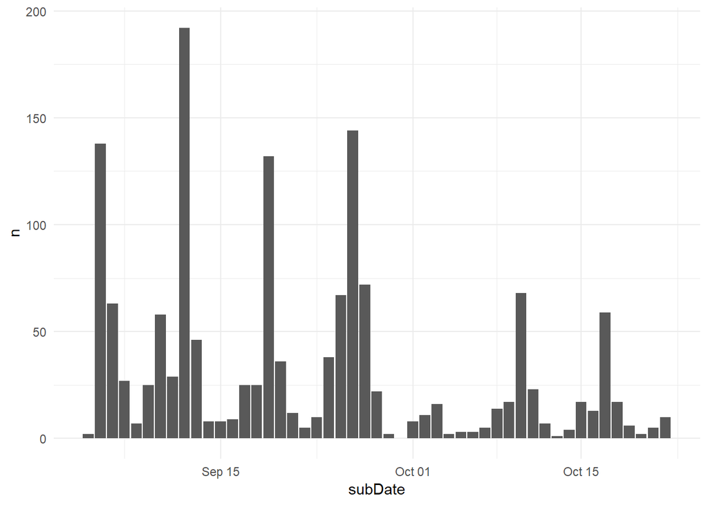

What percent of students have submitted assignments?

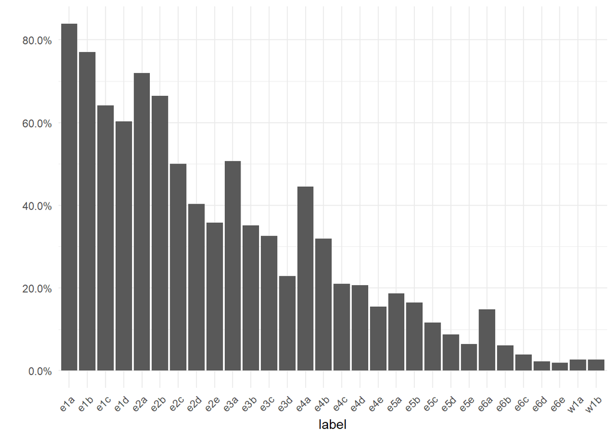

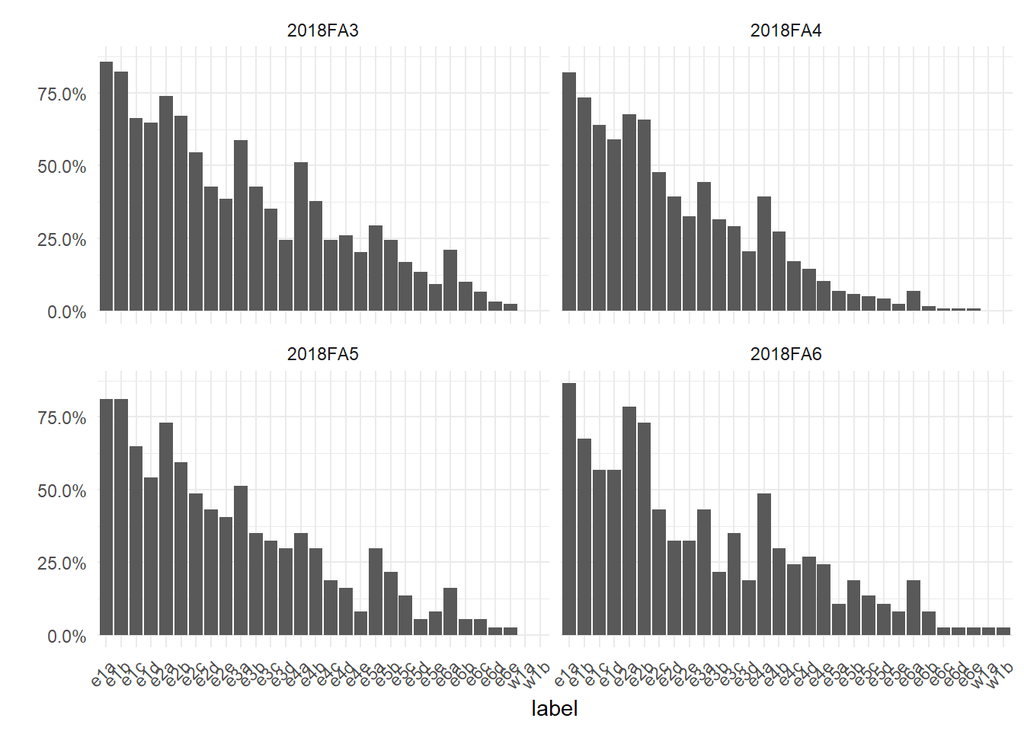

Of the students that have submitted an assignment, what percent submitted multiple times?

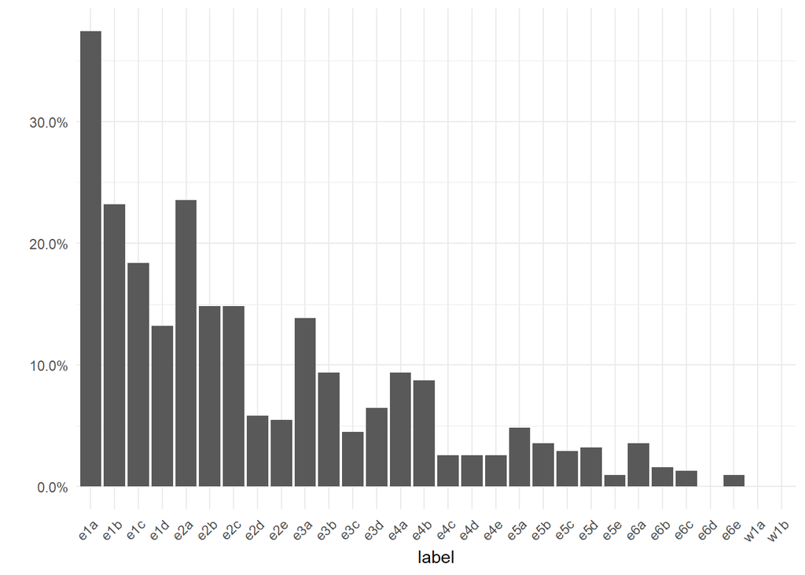

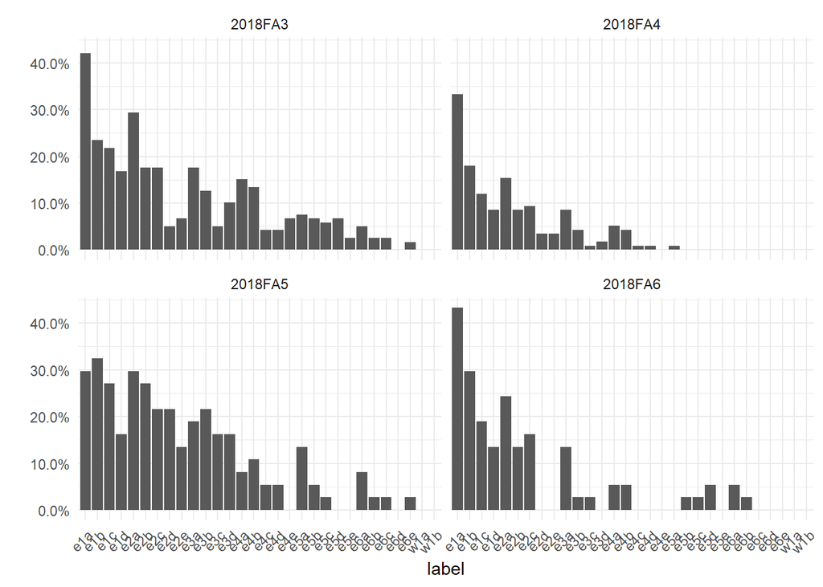

How many students have not submitted any files (per chunk)?

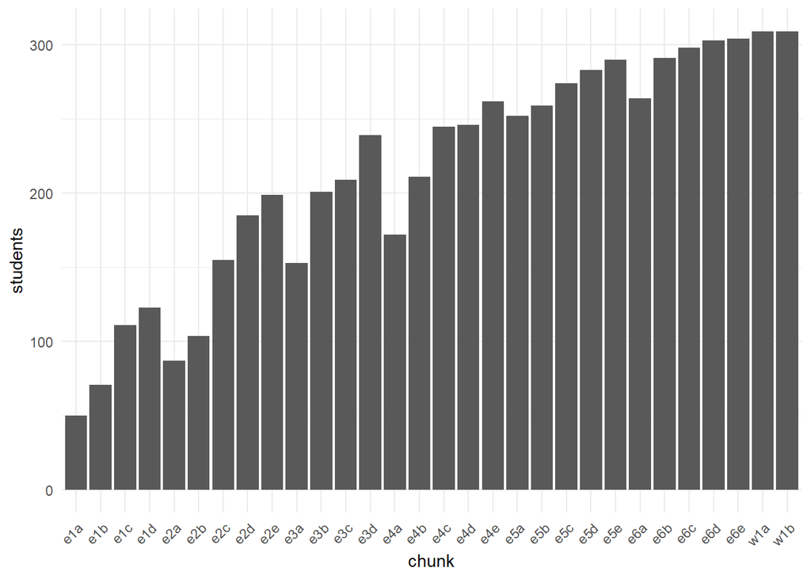

Students that have not submitted any files for e1a: mpruit4, vchiu1, adurha3, tsand39, cweint1, cpoull1, mdanfo2, mcromw2, jnewbo1, aparti4, jgeor32, aford48, ccamp59, rennet1, ztayl12, dkatzm1, tpayne8, mmeye31, jdaly6, cours11, dsloan6, sarago1, pmitc18, sostra1, rhugue4, aberr19, pgreay1, ctimes1, oferna2, tjunea6, jpulei1, cquinl2, mjoh356, clundg3, bbares2, crepp1, rshaw13, gwoolw1, lrase1, rhayne8, ccarm11, dsmi286, kainsw2, adav236, wcansl1, jwal144, kwatzk1, aburgo6, jshelb5, bloupe4

#### Attendance

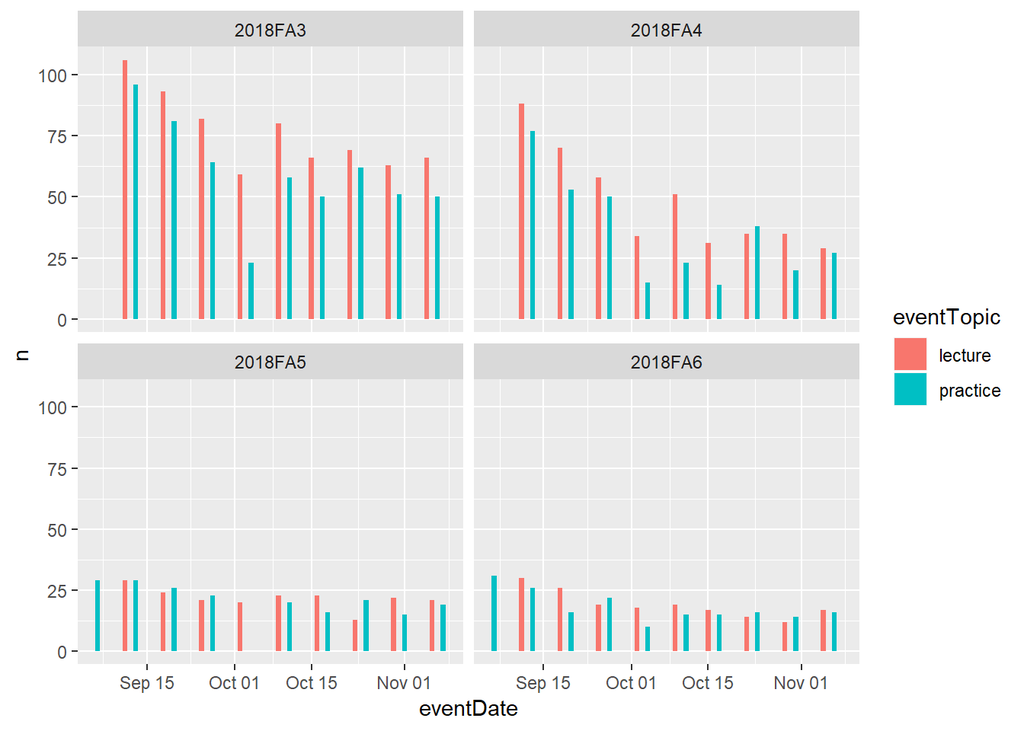

### Links

What students have clicked the links on the syllabus page?

| pawsId | eventLabel |
| --- | --- |
| ckoncz1 | https://business.lsu.edu/OBSS/Pages/About-Us.aspx |
| ckoncz1 | https://www.cornell.edu/ |
| cmayna5 | https://grok.lsu.edu/article.aspx?articleId=17762 |
| cquinl2 | https://sites01.lsu.edu/wp/policiesprocedures/policies-procedures/22/ |
| dpoor1 | http://www.lsu.edu/students/careercenter/files/2017.2018StudentCareerGuide.newdigital.pdf |
| echri19 | http://www.lsu.edu/students/careercenter/files/2017.2018StudentCareerGuide.newdigital.pdf |
| hchilm1 | http://www.lsu.edu/students/careercenter/files/2017.2018StudentCareerGuide.newdigital.pdf |
| hwrig16 | https://grok.lsu.edu/article.aspx?articleId=17762 |
| jmoham7 | https://business.lsu.edu/OBSS/Pages/About-Us.aspx |
| kconer5 | http://www.lsu.edu/students/careercenter/files/2017.2018StudentCareerGuide.newdigital.pdf |
| lande49 | https://grok.lsu.edu/article.aspx?articleId=17762 |
| mmoshe3 | http://www.lsu.edu/students/careercenter/files/2017.2018StudentCareerGuide.newdigital.pdf |
| mmoshe3 | https://business.lsu.edu/OBSS/Pages/About-Us.aspx |
| mnarci1 | https://www.brookings.edu/research/for-better-learning-in-college-lectures-lay-down-the-laptop-and-pick-up-a-pen/ |
| mperni3 | https://grok.lsu.edu/article.aspx?articleId=17762 |
| narger1 | https://grok.lsu.edu/article.aspx?articleId=17762 |
| pmitc18 | https://www.merriam-webster.com/dictionary/proficient |
| rweiss3 | https://business.lsu.edu/OBSS/Pages/About-Us.aspx |
| smoure2 | https://www.brookings.edu/research/for-better-learning-in-college-lectures-lay-down-the-laptop-and-pick-up-a-pen/ |
| swainw1 | https://grok.lsu.edu/article.aspx?articleId=17762 |
| tdang23 | https://business.lsu.edu/OBSS/Pages/About-Us.aspx |
| vchiu1 | http://www.lsu.edu/students/careercenter/files/2017.2018StudentCareerGuide.newdigital.pdf |

What pages are students clicking links from?

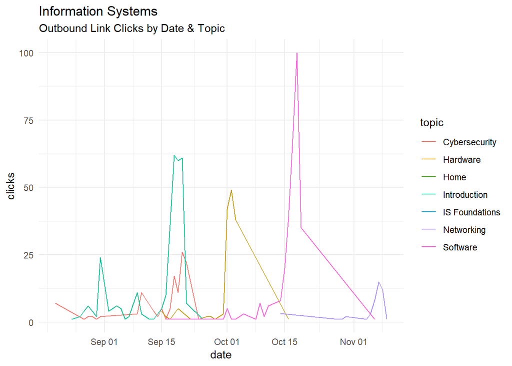

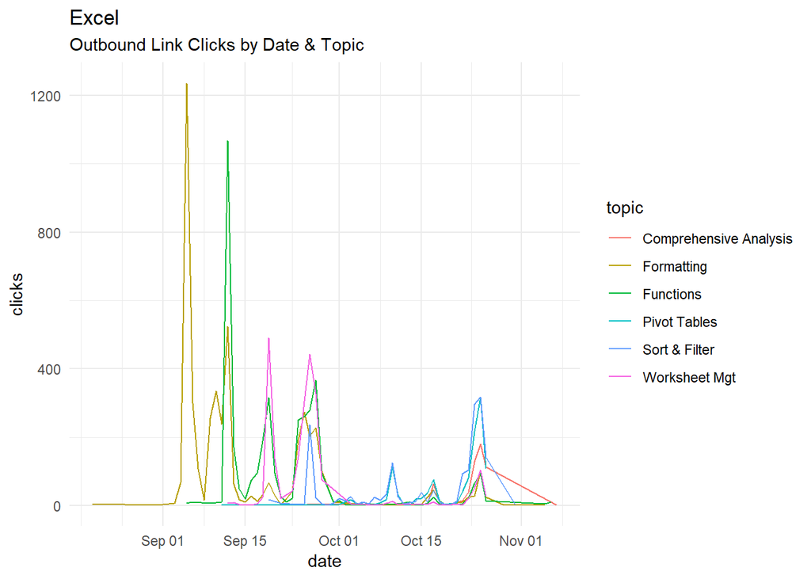

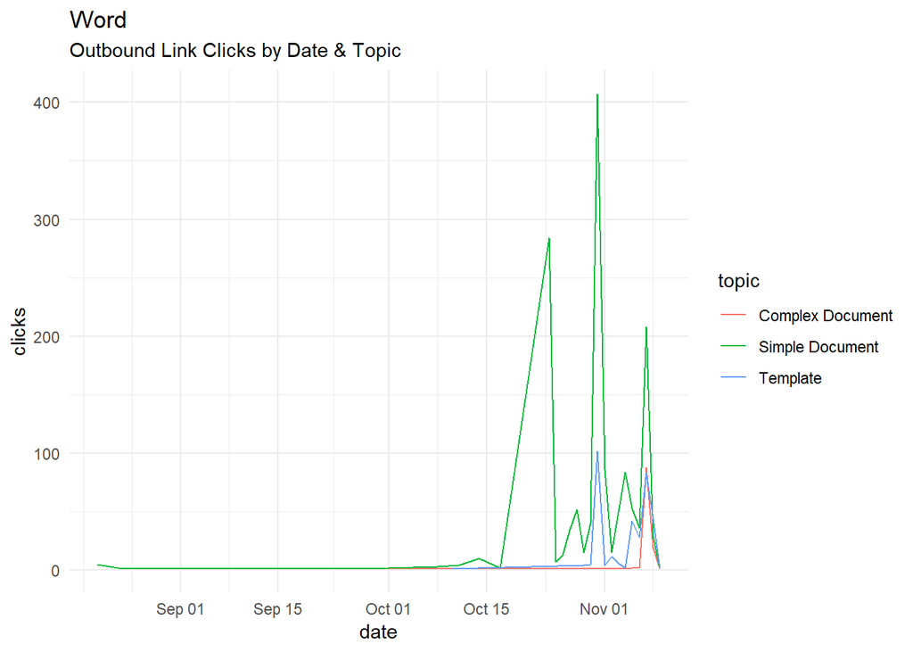